# ANOVA

May 11, 2016

## usage(可以之后删掉)

- 'f' enable fullscreen mode
- 'w' toggle widescreen mode
- 'o' enable overview mode
- 'h' enable code highlight mode
- 'p' show presenter notes

## outline(可以之后删掉)

(1)Basic function

avo();summery();#One-way ANOVA;

(2)Optional

manova()

Two-way ANOVA; Interaction in ANOVA analysis;

(3)Review

Use box plots and line plots to visualize group differences.

interaction.plot()

plotmeans()

## One-Way ANOVA

## Sample

A class is divided up into study groups with different vitamin treatment. All members of a class take a test. Data are the height of the students divided up by treatment.

| Treatment 1 | Treatment 2 | Treatment 3 | Treatment 4 |
| --- | --- | --- | --- |
| 89 | 88 | 63 | 59 |
| 85 | 72 | 57 | 42 |
| 98 | 63 | 43 | 41 |
| 80 | 82 | 60 | 51 |
| 96 | 75 |  |  |

## Data

```r
df1 <- data.frame(height=c(85, 89, 96, 80, 98), group="treat1")
df2 <- data.frame(height=c(72, 88, 75, 82, 63), group="treat2")
df3 <- data.frame(height=c(43, 57, 63, 60)    , group="treat3")
df4 <- data.frame(height=c(51, 42, 59, 41)    , group="treat4")
mydata <- rbind(df1,df2,df3,df4)
mydata
```

```
##    height  group
## 1      85 treat1
## 2      89 treat1
## 3      96 treat1
## 4      80 treat1
## 5      98 treat1
## 6      72 treat2
## 7      88 treat2
## 8      75 treat2
## 9      82 treat2
## 10     63 treat2
## 11     43 treat3
## 12     57 treat3
## 13     63 treat3
## 14     60 treat3
## 15     51 treat4
## 16     42 treat4
## 17     59 treat4
## 18     41 treat4
```

## Plot the data

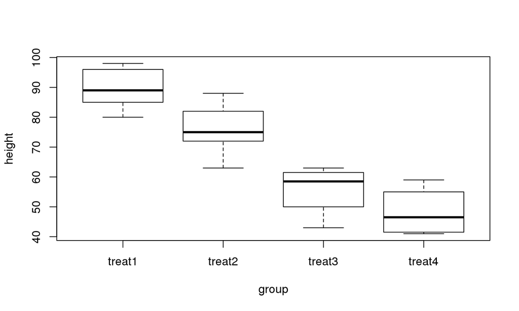

```r
plot(height~group, data=mydata)
```

## Test the homogeneity of variance

```r
bartlett.test(height~group, data=mydata)
```

```
##
##  Bartlett test of homogeneity of variances
##
## data:  height by group
## Bartlett's K-squared = 0.21381, df = 3, p-value = 0.9753
```

p-value > 0.05, and accept null hypothesis.

## One-Way ANOVA

```r
summary(aov(height~group, data=mydata))
```

```
##             Df Sum Sq Mean Sq F value   Pr(>F)
## group        3   4791  1597.0   21.48 1.66e-05 ***
## Residuals   14   1041    74.3
## ---
## Signif. codes:  0 '***' 0.001 '**' 0.01 '*' 0.05 '.' 0.1 ' ' 1
```

## Two-Way ANOVA

## Sample

A new fertilizer has been developed to increase the yield on crops, and the makers of the fertilizer want to better understand which of the three formulations (blends) of this fertilizer are most effective for wheat, corn, soy beans and rice (crops). They test each of the three blends on one sample of each of the four types of crops. The crop yields for the 12 combinations are as shown in the following figure. Run an `F test` to test the effect of fertilizer and crops.

|  | Wheat | Corn | Soy | Rice |
| --- | --- | --- | --- | --- |
| Blend X | 123 | 138 | 110 | 151 |
| Blend Y | 145 | 165 | 140 | 167 |
| Blend Z | 156 | 176 | 185 | 175 |

## Data

```r
blendx <- c(123, 138, 110, 151)
blendy <- c(145, 165, 140, 167)
blendz <- c(156, 176, 185, 175)
fulldata <- c(blendx, blendy, blendz)
# levels
crops <- gl(4,1,length=12, labels=c("Wheat","Corn","Soy","Rice"))
crops
```

```
##  [1] Wheat Corn  Soy   Rice  Wheat Corn  Soy   Rice  Wheat Corn  Soy
## [12] Rice
## Levels: Wheat Corn Soy Rice
```

```r
blend <- gl(3,4,length=12, labels=c("Blend X","Blend Y","Blend Z") )
blend
```

```
##  [1] Blend X Blend X Blend X Blend X Blend Y Blend Y Blend Y Blend Y
##  [9] Blend Z Blend Z Blend Z Blend Z
## Levels: Blend X Blend Y Blend Z
```

## Data

```r
mydata <- data.frame(yields=fulldata, crops, blend)
mydata
```

```
##    yields crops   blend
## 1     123 Wheat Blend X
## 2     138  Corn Blend X
## 3     110   Soy Blend X
## 4     151  Rice Blend X
## 5     145 Wheat Blend Y
## 6     165  Corn Blend Y
## 7     140   Soy Blend Y
## 8     167  Rice Blend Y
## 9     156 Wheat Blend Z
## 10    176  Corn Blend Z
## 11    185   Soy Blend Z
## 12    175  Rice Blend Z
```

## Test the homogeneity of variance

**Null hypothesis**: all populations variances are equal.

```r
bartlett.test(split(fulldata,list(crops,blend)))
```

"there must be at least 2 observations in each group."

so just jump this step.

## Two-Way ANOVA

```r
summary(aov(yields~crops+blend,data=mydata))
```

```
##             Df Sum Sq Mean Sq F value  Pr(>F)
## crops        3   1117   372.3   2.632 0.14456
## blend        2   3629  1814.6  12.826 0.00681 **
## Residuals    6    849   141.5
## ---
## Signif. codes:  0 '***' 0.001 '**' 0.01 '*' 0.05 '.' 0.1 ' ' 1
```

- p-value(crops) > 0.05, fail to reject null hypothesis.
- p-value(blend) < 0.05, reject null hypothesis, fertilizers have different effect on crops.

## Diagnostic Plots

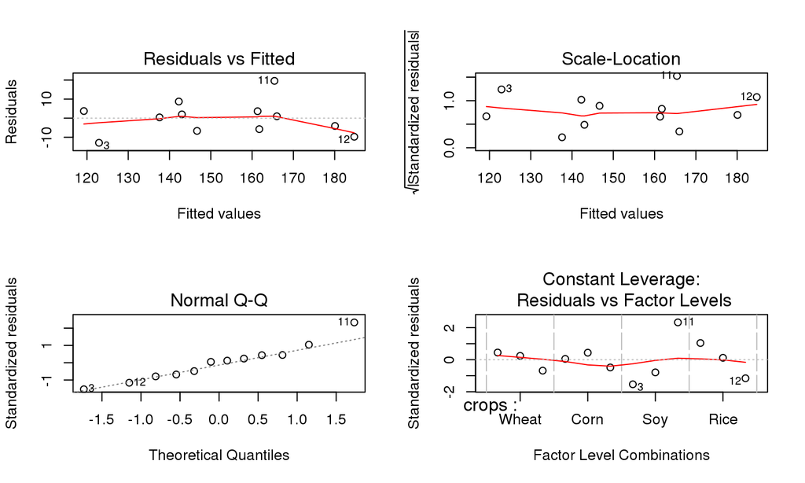

```r
layout(matrix(c(1,2,3,4),2,2)) # optional layout
plot( aov(yields~crops+blend,data=mydata) )
```

## Visualizing Results

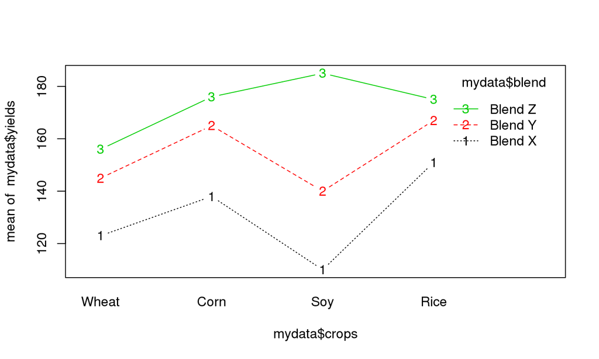

```r
# Two-way Interaction Plot
interaction.plot(mydata$crops, mydata$blend, mydata$yields, type="b", col=c(1:3))
```

## MANOVA

If there is more than one dependent (outcome) variable, you can test them simultaneously using a **multivariate analysis of variance** (MANOVA). In the following example, let Y be a matrix whose columns are the dependent variables.

```r
# 2x2 Factorial MANOVA with 3 Dependent Variables.
Y <- cbind(y1,y2,y3)
fit <- manova(Y ~ A*B)
summary(fit, test="Pillai")
```

Other test options are "Wilks", "Hotelling-Lawley", and "Roy". Use summary.aov( ) to get univariate statistics. TukeyHSD( ) and plot( ) will not work with a MANOVA fit. Run each dependent variable separately to obtain them. Like ANOVA, MANOVA results in R are based on Type I SS. To obtain Type III SS, vary the order of variables in the model and rerun the analyses. For example, fit y~A*B for the TypeIII B effect and y~B*A for the Type III A effect.

## Exercise

## Exercise 1

A manufactory produce mechanical parts, here is a batch of these production and the size (cm) are listed below. Is there a difference (a=0.05) beween these groups?

| Gp 1 | Gp 2 | Gp 3 | Gp 4 |
| --- | --- | --- | --- |
| 85 | 72 | 43 | 51 |
| 89 | 88 | 57 | 42 |
| 96 | 75 | 63 | 59 |
| 80 | 82 | 60 | 41 |
| 98 | 63 |  |  |

## Exercise 2

Run Anova to test the effect of age-range,race and their interaction on exercise time(hour) per month.

| Race/Age | 0~16 | 17~35 | 35~50 |
| --- | --- | --- | --- |
| Black | 40 | 32 | 30 |
|  | 36 | 29 | 35 |
|  | 38 | 36 | 33 |
| Yellow | 24 | 20 | 18 |
|  | 21 | 29 | 26 |
|  | 20 | 25 | 26 |
| White | 22 | 20 | 18 |
|  | 18 | 18 | 14 |
|  | 16 | 19 | 19 |